# Results: Diskriminant Analizi.sas

The FREQ Procedure

| trt | Frequency | Percent | Cumulative Frequency | Cumulative Percent |
| --- | --- | --- | --- | --- |
| 0 | 532 | 24.87 | 532 | 24.87 |
| 1 | 522 | 24.40 | 1054 | 49.28 |
| 2 | 524 | 24.50 | 1578 | 73.77 |
| 3 | 561 | 26.23 | 2139 | 100.00 |

The CORR Procedure

| 4 Variables: | cd40 cd420 cd80 cd820 |
| --- | --- |

| Simple Statistics Variable | Simple Statistics N | Simple Statistics Mean | Simple Statistics Std Dev | Simple Statistics Median | Simple Statistics Minimum | Simple Statistics Maximum |
| --- | --- | --- | --- | --- | --- | --- |
| cd40 | 2139 | 350.50117 | 118.57386 | 340.00000 | 0 | 1199 |
| cd420 | 2139 | 371.30715 | 144.63491 | 353.00000 | 49.00000 | 1119 |
| cd80 | 2139 | 986.62740 | 480.19775 | 893.00000 | 40.00000 | 5011 |
| cd820 | 2139 | 935.36980 | 444.97605 | 865.00000 | 124.00000 | 6035 |

| Spearman Correlation Coefficients, N = 2139 Prob > \|r\| under H0: Rho=0 | Spearman Correlation Coefficients, N = 2139 Prob > \|r\| under H0: Rho=0 cd40 | Spearman Correlation Coefficients, N = 2139 Prob > \|r\| under H0: Rho=0 cd420 | Spearman Correlation Coefficients, N = 2139 Prob > \|r\| under H0: Rho=0 cd80 | Spearman Correlation Coefficients, N = 2139 Prob > \|r\| under H0: Rho=0 cd820 |
| --- | --- | --- | --- | --- |
| cd40 | 1.00000 | 0.62000 <.0001 | 0.22833 <.0001 | 0.07801 0.0003 |
| cd420 | 0.62000 <.0001 | 1.00000 | 0.05950 0.0059 | 0.21822 <.0001 |
| cd80 | 0.22833 <.0001 | 0.05950 0.0059 | 1.00000 | 0.74151 <.0001 |
| cd820 | 0.07801 0.0003 | 0.21822 <.0001 | 0.74151 <.0001 | 1.00000 |

The UNIVARIATE Procedure

Variable: cd40

| Moments |  |  |  |
| --- | --- | --- | --- |
| N | 2139 | Sum Weights | 2139 |
| Mean | 350.501169 | Sum Observations | 749722 |
| Std Deviation | 118.573863 | Variance | 14059.7609 |
| Skewness | 0.75786782 | Kurtosis | 1.80541067 |
| Uncorrected SS | 292838206 | Corrected SS | 30059768.7 |
| Coeff Variation | 33.8298052 | Std Error Mean | 2.56379664 |

| Basic Statistical Measures Location | Basic Statistical Measures Location | Basic Statistical Measures Variability | Basic Statistical Measures Variability |
| --- | --- | --- | --- |
| Mean | 350.5012 | Std Deviation | 118.57386 |
| Median | 340.0000 | Variance | 14060 |
| Mode | 300.0000 | Range | 1199 |
|  |  | Interquartile Range | 160.00000 |

| Tests for Location: Mu0=0 Test | Tests for Location: Mu0=0 Statistic | Tests for Location: Mu0=0 Statistic | Tests for Location: Mu0=0 p Value | Tests for Location: Mu0=0 p Value |
| --- | --- | --- | --- | --- |
| Student's t | t | 136.7118 | Pr > \|t\| | <.0001 |
| Sign | M | 1068 | Pr >= \|M\| | <.0001 |
| Signed Rank | S | 1141158 | Pr >= \|S\| | <.0001 |

| Tests for Normality Test | Tests for Normality Statistic | Tests for Normality Statistic | Tests for Normality p Value | Tests for Normality p Value |
| --- | --- | --- | --- | --- |
| Kolmogorov-Smirnov | D | 0.04705 | Pr > D | <0.0100 |
| Cramer-von Mises | W-Sq | 1.260355 | Pr > W-Sq | <0.0050 |
| Anderson-Darling | A-Sq | 8.914103 | Pr > A-Sq | <0.0050 |

| Quantiles (Definition 5) Level | Quantiles (Definition 5) Quantile |
| --- | --- |
| 100% Max | 1199 |
| 99% | 689 |
| 95% | 549 |
| 90% | 500 |
| 75% Q3 | 423 |
| 50% Median | 340 |
| 25% Q1 | 263 |
| 10% | 211 |
| 5% | 182 |
| 1% | 142 |
| 0% Min | 0 |

| Extreme Observations Lowest Value | Extreme Observations Lowest Obs | Extreme Observations Highest Value | Extreme Observations Highest Obs |
| --- | --- | --- | --- |
| 0 | 724 | 775 | 570 |
| 0 | 218 | 834 | 426 |
| 0 | 217 | 911 | 2139 |
| 70 | 1456 | 918 | 1482 |
| 84 | 286 | 1199 | 1145 |

The UNIVARIATE Procedure

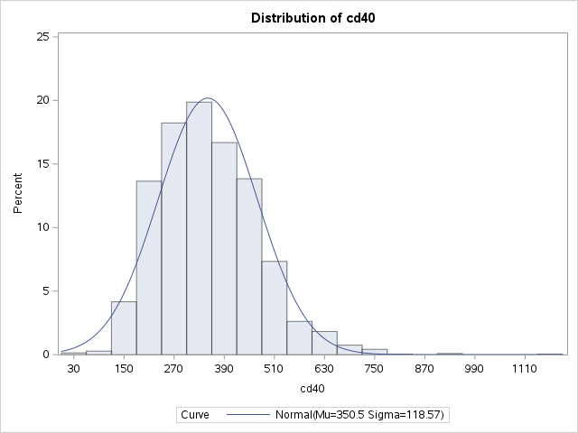

The UNIVARIATE Procedure

Fitted Normal Distribution for cd40

| Parameters for Normal Distribution Parameter | Parameters for Normal Distribution Symbol | Parameters for Normal Distribution Estimate |
| --- | --- | --- |
| Mean | Mu | 350.5012 |
| Std Dev | Sigma | 118.5739 |

| Goodness-of-Fit Tests for Normal Distribution Test | Goodness-of-Fit Tests for Normal Distribution Statistic | Goodness-of-Fit Tests for Normal Distribution Statistic | Goodness-of-Fit Tests for Normal Distribution p Value | Goodness-of-Fit Tests for Normal Distribution p Value |
| --- | --- | --- | --- | --- |
| Kolmogorov-Smirnov | D | 0.04705008 | Pr > D | <0.010 |
| Cramer-von Mises | W-Sq | 1.26035514 | Pr > W-Sq | <0.005 |
| Anderson-Darling | A-Sq | 8.91410251 | Pr > A-Sq | <0.005 |

| Quantiles for Normal Distribution Percent | Quantiles for Normal Distribution Quantile Observed | Quantiles for Normal Distribution Quantile Estimated |
| --- | --- | --- |
| 1.0 | 142.000 | 74.6571 |
| 5.0 | 182.000 | 155.4645 |
| 10.0 | 211.000 | 198.5426 |
| 25.0 | 263.000 | 270.5243 |
| 50.0 | 340.000 | 350.5012 |
| 75.0 | 423.000 | 430.4780 |
| 90.0 | 500.000 | 502.4597 |
| 95.0 | 549.000 | 545.5378 |
| 99.0 | 689.000 | 626.3452 |

The UNIVARIATE Procedure

Variable: cd420

| Moments |  |  |  |
| --- | --- | --- | --- |
| N | 2139 | Sum Weights | 2139 |
| Mean | 371.307153 | Sum Observations | 794226 |
| Std Deviation | 144.634909 | Variance | 20919.2569 |
| Skewness | 0.73034654 | Kurtosis | 1.07105536 |
| Uncorrected SS | 339627166 | Corrected SS | 44725371.2 |
| Coeff Variation | 38.9529013 | Std Error Mean | 3.12728696 |

| Basic Statistical Measures Location | Basic Statistical Measures Location | Basic Statistical Measures Variability | Basic Statistical Measures Variability |
| --- | --- | --- | --- |
| Mean | 371.3072 | Std Deviation | 144.63491 |
| Median | 353.0000 | Variance | 20919 |
| Mode | 300.0000 | Range | 1070 |
|  |  | Interquartile Range | 191.00000 |

| Tests for Location: Mu0=0 Test | Tests for Location: Mu0=0 Statistic | Tests for Location: Mu0=0 Statistic | Tests for Location: Mu0=0 p Value | Tests for Location: Mu0=0 p Value |
| --- | --- | --- | --- | --- |
| Student's t | t | 118.7314 | Pr > \|t\| | <.0001 |
| Sign | M | 1069.5 | Pr >= \|M\| | <.0001 |
| Signed Rank | S | 1144365 | Pr >= \|S\| | <.0001 |

| Tests for Normality Test | Tests for Normality Statistic | Tests for Normality Statistic | Tests for Normality p Value | Tests for Normality p Value |
| --- | --- | --- | --- | --- |
| Kolmogorov-Smirnov | D | 0.051998 | Pr > D | <0.0100 |
| Cramer-von Mises | W-Sq | 1.784729 | Pr > W-Sq | <0.0050 |
| Anderson-Darling | A-Sq | 10.84697 | Pr > A-Sq | <0.0050 |

| Quantiles (Definition 5) Level | Quantiles (Definition 5) Quantile |
| --- | --- |
| 100% Max | 1119 |
| 99% | 772 |
| 95% | 619 |
| 90% | 565 |
| 75% Q3 | 460 |
| 50% Median | 353 |
| 25% Q1 | 269 |
| 10% | 200 |
| 5% | 163 |
| 1% | 101 |
| 0% Min | 49 |

| Extreme Observations Lowest Value | Extreme Observations Lowest Obs | Extreme Observations Highest Value | Extreme Observations Highest Obs |
| --- | --- | --- | --- |
| 49 | 1530 | 955 | 1920 |
| 50 | 1363 | 980 | 1782 |
| 52 | 1170 | 1040 | 399 |
| 53 | 2018 | 1100 | 133 |
| 74 | 397 | 1119 | 168 |

The UNIVARIATE Procedure

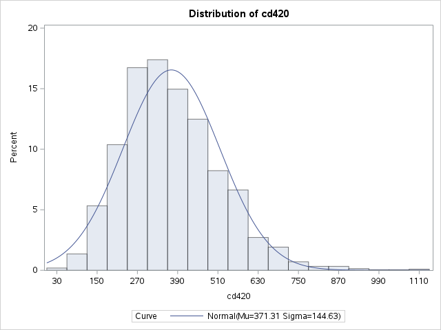

The UNIVARIATE Procedure

Fitted Normal Distribution for cd420

| Parameters for Normal Distribution Parameter | Parameters for Normal Distribution Symbol | Parameters for Normal Distribution Estimate |
| --- | --- | --- |
| Mean | Mu | 371.3072 |
| Std Dev | Sigma | 144.6349 |

| Goodness-of-Fit Tests for Normal Distribution Test | Goodness-of-Fit Tests for Normal Distribution Statistic | Goodness-of-Fit Tests for Normal Distribution Statistic | Goodness-of-Fit Tests for Normal Distribution p Value | Goodness-of-Fit Tests for Normal Distribution p Value |
| --- | --- | --- | --- | --- |
| Kolmogorov-Smirnov | D | 0.0519979 | Pr > D | <0.010 |
| Cramer-von Mises | W-Sq | 1.7847286 | Pr > W-Sq | <0.005 |
| Anderson-Darling | A-Sq | 10.8469743 | Pr > A-Sq | <0.005 |

| Quantiles for Normal Distribution Percent | Quantiles for Normal Distribution Quantile Observed | Quantiles for Normal Distribution Quantile Estimated |
| --- | --- | --- |
| 1.0 | 101.000 | 34.8360 |
| 5.0 | 163.000 | 133.4039 |
| 10.0 | 200.000 | 185.9501 |
| 25.0 | 269.000 | 273.7524 |
| 50.0 | 353.000 | 371.3072 |
| 75.0 | 460.000 | 468.8619 |
| 90.0 | 565.000 | 556.6642 |
| 95.0 | 619.000 | 609.2104 |
| 99.0 | 772.000 | 707.7783 |

The UNIVARIATE Procedure

Variable: cd80

| Moments |  |  |  |
| --- | --- | --- | --- |
| N | 2139 | Sum Weights | 2139 |
| Mean | 986.627396 | Sum Observations | 2110396 |
| Std Deviation | 480.19775 | Variance | 230589.879 |
| Skewness | 1.73373587 | Kurtosis | 6.1789811 |
| Uncorrected SS | 2575175672 | Corrected SS | 493001162 |
| Coeff Variation | 48.6706281 | Std Error Mean | 10.3828057 |

| Basic Statistical Measures Location | Basic Statistical Measures Location | Basic Statistical Measures Variability | Basic Statistical Measures Variability |
| --- | --- | --- | --- |
| Mean | 986.6274 | Std Deviation | 480.19775 |
| Median | 893.0000 | Variance | 230590 |
| Mode | 620.0000 | Range | 4971 |
|  |  | Interquartile Range | 554.00000 |

Note: The mode displayed is the smallest of 3 modes with a count of 10.

| Tests for Location: Mu0=0 Test | Tests for Location: Mu0=0 Statistic | Tests for Location: Mu0=0 Statistic | Tests for Location: Mu0=0 p Value | Tests for Location: Mu0=0 p Value |
| --- | --- | --- | --- | --- |
| Student's t | t | 95.02512 | Pr > \|t\| | <.0001 |
| Sign | M | 1069.5 | Pr >= \|M\| | <.0001 |
| Signed Rank | S | 1144365 | Pr >= \|S\| | <.0001 |

| Tests for Normality Test | Tests for Normality Statistic | Tests for Normality Statistic | Tests for Normality p Value | Tests for Normality p Value |
| --- | --- | --- | --- | --- |
| Kolmogorov-Smirnov | D | 0.091977 | Pr > D | <0.0100 |
| Cramer-von Mises | W-Sq | 6.963081 | Pr > W-Sq | <0.0050 |
| Anderson-Darling | A-Sq | 42.73705 | Pr > A-Sq | <0.0050 |

| Quantiles (Definition 5) Level | Quantiles (Definition 5) Quantile |
| --- | --- |
| 100% Max | 5011 |
| 99% | 2666 |
| 95% | 1853 |
| 90% | 1574 |
| 75% Q3 | 1208 |
| 50% Median | 893 |
| 25% Q1 | 654 |
| 10% | 502 |
| 5% | 410 |
| 1% | 274 |
| 0% Min | 40 |

| Extreme Observations Lowest Value | Extreme Observations Lowest Obs | Extreme Observations Highest Value | Extreme Observations Highest Obs |
| --- | --- | --- | --- |
| 40 | 601 | 3389 | 426 |
| 105 | 1668 | 3780 | 1562 |
| 116 | 1418 | 3827 | 1608 |
| 137 | 797 | 4255 | 1938 |
| 176 | 2073 | 5011 | 2125 |

The UNIVARIATE Procedure

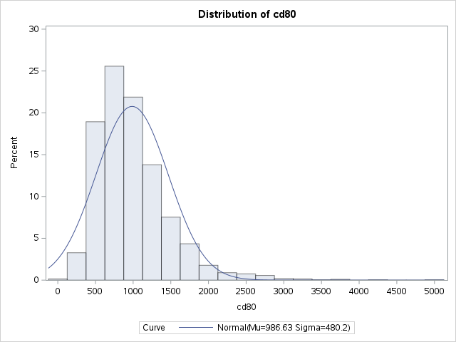

The UNIVARIATE Procedure

Fitted Normal Distribution for cd80

| Parameters for Normal Distribution Parameter | Parameters for Normal Distribution Symbol | Parameters for Normal Distribution Estimate |
| --- | --- | --- |
| Mean | Mu | 986.6274 |
| Std Dev | Sigma | 480.1978 |

| Goodness-of-Fit Tests for Normal Distribution Test | Goodness-of-Fit Tests for Normal Distribution Statistic | Goodness-of-Fit Tests for Normal Distribution Statistic | Goodness-of-Fit Tests for Normal Distribution p Value | Goodness-of-Fit Tests for Normal Distribution p Value |
| --- | --- | --- | --- | --- |
| Kolmogorov-Smirnov | D | 0.0919772 | Pr > D | <0.010 |
| Cramer-von Mises | W-Sq | 6.9630809 | Pr > W-Sq | <0.005 |
| Anderson-Darling | A-Sq | 42.7370479 | Pr > A-Sq | <0.005 |

| Quantiles for Normal Distribution Percent | Quantiles for Normal Distribution Quantile Observed | Quantiles for Normal Distribution Quantile Estimated |
| --- | --- | --- |
| 1.0 | 274.000 | -130.480 |
| 5.0 | 410.000 | 196.772 |
| 10.0 | 502.000 | 371.229 |
| 25.0 | 654.000 | 662.739 |
| 50.0 | 893.000 | 986.627 |
| 75.0 | 1208.000 | 1310.516 |
| 90.0 | 1574.000 | 1602.026 |
| 95.0 | 1853.000 | 1776.482 |
| 99.0 | 2666.000 | 2103.734 |

The UNIVARIATE Procedure

Variable: cd820

| Moments |  |  |  |
| --- | --- | --- | --- |
| N | 2139 | Sum Weights | 2139 |
| Mean | 935.369799 | Sum Observations | 2000756 |
| Std Deviation | 444.976051 | Variance | 198003.686 |
| Skewness | 2.09142657 | Kurtosis | 11.7708101 |
| Uncorrected SS | 2294778618 | Corrected SS | 423331880 |
| Coeff Variation | 47.5722064 | Std Error Mean | 9.62124436 |

| Basic Statistical Measures Location | Basic Statistical Measures Location | Basic Statistical Measures Variability | Basic Statistical Measures Variability |
| --- | --- | --- | --- |
| Mean | 935.3698 | Std Deviation | 444.97605 |
| Median | 865.0000 | Variance | 198004 |
| Mode | 730.0000 | Range | 5911 |
|  |  | Interquartile Range | 516.00000 |

Note: The mode displayed is the smallest of 2 modes with a count of 11.

| Tests for Location: Mu0=0 Test | Tests for Location: Mu0=0 Statistic | Tests for Location: Mu0=0 Statistic | Tests for Location: Mu0=0 p Value | Tests for Location: Mu0=0 p Value |
| --- | --- | --- | --- | --- |
| Student's t | t | 97.21921 | Pr > \|t\| | <.0001 |
| Sign | M | 1069.5 | Pr >= \|M\| | <.0001 |
| Signed Rank | S | 1144365 | Pr >= \|S\| | <.0001 |

| Tests for Normality Test | Tests for Normality Statistic | Tests for Normality Statistic | Tests for Normality p Value | Tests for Normality p Value |
| --- | --- | --- | --- | --- |
| Kolmogorov-Smirnov | D | 0.083396 | Pr > D | <0.0100 |
| Cramer-von Mises | W-Sq | 6.344866 | Pr > W-Sq | <0.0050 |
| Anderson-Darling | A-Sq | 40.29434 | Pr > A-Sq | <0.0050 |

| Quantiles (Definition 5) Level | Quantiles (Definition 5) Quantile |
| --- | --- |
| 100% Max | 6035 |
| 99% | 2486 |
| 95% | 1750 |
| 90% | 1457 |
| 75% Q3 | 1147 |
| 50% Median | 865 |
| 25% Q1 | 631 |
| 10% | 481 |
| 5% | 399 |
| 1% | 280 |
| 0% Min | 124 |

| Extreme Observations Lowest Value | Extreme Observations Lowest Obs | Extreme Observations Highest Value | Extreme Observations Highest Obs |
| --- | --- | --- | --- |
| 124 | 2073 | 3130 | 1998 |
| 131 | 9 | 3407 | 1237 |
| 140 | 1994 | 3552 | 1562 |
| 150 | 1363 | 4113 | 908 |
| 173 | 1668 | 6035 | 2125 |

The UNIVARIATE Procedure

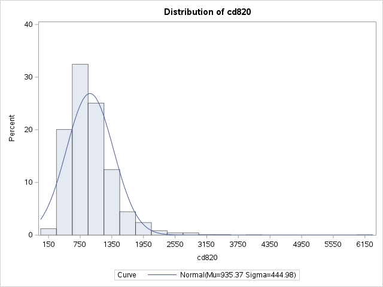

The UNIVARIATE Procedure

Fitted Normal Distribution for cd820

| Parameters for Normal Distribution Parameter | Parameters for Normal Distribution Symbol | Parameters for Normal Distribution Estimate |
| --- | --- | --- |
| Mean | Mu | 935.3698 |
| Std Dev | Sigma | 444.9761 |

| Goodness-of-Fit Tests for Normal Distribution Test | Goodness-of-Fit Tests for Normal Distribution Statistic | Goodness-of-Fit Tests for Normal Distribution Statistic | Goodness-of-Fit Tests for Normal Distribution p Value | Goodness-of-Fit Tests for Normal Distribution p Value |
| --- | --- | --- | --- | --- |
| Kolmogorov-Smirnov | D | 0.0833964 | Pr > D | <0.010 |
| Cramer-von Mises | W-Sq | 6.3448660 | Pr > W-Sq | <0.005 |
| Anderson-Darling | A-Sq | 40.2943360 | Pr > A-Sq | <0.005 |

| Quantiles for Normal Distribution Percent | Quantiles for Normal Distribution Quantile Observed | Quantiles for Normal Distribution Quantile Estimated |
| --- | --- | --- |
| 1.0 | 280.000 | -99.7993 |
| 5.0 | 399.000 | 203.4493 |
| 10.0 | 481.000 | 365.1100 |
| 25.0 | 631.000 | 635.2380 |
| 50.0 | 865.000 | 935.3698 |
| 75.0 | 1147.000 | 1235.5016 |
| 90.0 | 1457.000 | 1505.6296 |
| 95.0 | 1750.000 | 1667.2903 |
| 99.0 | 2486.000 | 1970.5389 |

The DISCRIM Procedure

| Total Sample Size | 2139 | DF Total | 2138 |
| --- | --- | --- | --- |
| Variables | 4 | DF Within Classes | 2135 |
| Classes | 4 | DF Between Classes | 3 |

| Number of Observations Read | 2139 |
| --- | --- |
| Number of Observations Used | 2139 |

| Class Level Information trt | Class Level Information Variable Name | Class Level Information Frequency | Class Level Information Weight | Class Level Information Proportion | Class Level Information Prior Probability |
| --- | --- | --- | --- | --- | --- |
| 0 | 0 | 532 | 532.0000 | 0.248714 | 0.248714 |
| 1 | 1 | 522 | 522.0000 | 0.244039 | 0.244039 |
| 2 | 2 | 524 | 524.0000 | 0.244974 | 0.244974 |
| 3 | 3 | 561 | 561.0000 | 0.262272 | 0.262272 |

The DISCRIM Procedure

Simple Statistics

| Total-Sample Variable | Total-Sample N | Total-Sample Sum | Total-Sample Mean | Total-Sample Variance | Total-Sample Standard Deviation |
| --- | --- | --- | --- | --- | --- |
| cd40 | 2139 | 749722 | 350.50117 | 14060 | 118.5739 |
| cd420 | 2139 | 794226 | 371.30715 | 20919 | 144.6349 |
| cd80 | 2139 | 2110396 | 986.62740 | 230590 | 480.1978 |
| cd820 | 2139 | 2000756 | 935.36980 | 198004 | 444.9761 |

| trt = 0 Variable | trt = 0 N | trt = 0 Sum | trt = 0 Mean | trt = 0 Variance | trt = 0 Standard Deviation |
| --- | --- | --- | --- | --- | --- |
| cd40 | 532 | 187905 | 353.20489 | 13020 | 114.1053 |
| cd420 | 532 | 178826 | 336.13910 | 17151 | 130.9616 |
| cd80 | 532 | 525217 | 987.25000 | 225838 | 475.2239 |
| cd820 | 532 | 493810 | 928.21429 | 192343 | 438.5698 |

| trt = 1 Variable | trt = 1 N | trt = 1 Sum | trt = 1 Mean | trt = 1 Variance | trt = 1 Standard Deviation |
| --- | --- | --- | --- | --- | --- |
| cd40 | 522 | 182034 | 348.72414 | 16952 | 130.1995 |
| cd420 | 522 | 210456 | 403.17241 | 24431 | 156.3041 |
| cd80 | 522 | 524253 | 1004 | 238110 | 487.9654 |
| cd820 | 522 | 505283 | 967.97510 | 193278 | 439.6344 |

| trt = 2 Variable | trt = 2 N | trt = 2 Sum | trt = 2 Mean | trt = 2 Variance | trt = 2 Standard Deviation |
| --- | --- | --- | --- | --- | --- |
| cd40 | 524 | 184854 | 352.77481 | 13341 | 115.5050 |
| cd420 | 524 | 194948 | 372.03817 | 18233 | 135.0304 |
| cd80 | 524 | 515671 | 984.10496 | 205044 | 452.8173 |
| cd820 | 524 | 472445 | 901.61260 | 162686 | 403.3438 |

| trt = 3 Variable | trt = 3 N | trt = 3 Sum | trt = 3 Mean | trt = 3 Variance | trt = 3 Standard Deviation |
| --- | --- | --- | --- | --- | --- |
| cd40 | 561 | 194929 | 347.46702 | 13077 | 114.3556 |
| cd420 | 561 | 209996 | 374.32442 | 21715 | 147.3597 |
| cd80 | 561 | 545255 | 971.93405 | 252679 | 502.6717 |
| cd820 | 561 | 529218 | 943.34759 | 239642 | 489.5325 |

| Within Covariance Matrix Information trt | Within Covariance Matrix Information Covariance Matrix Rank | Within Covariance Matrix Information Natural Log of the Determinant of the Covariance Matrix |
| --- | --- | --- |
| 0 | 4 | 42.01934 |
| 1 | 4 | 43.15348 |
| 2 | 4 | 41.97810 |
| 3 | 4 | 42.34580 |
| Pooled | 4 | 42.44160 |

The DISCRIM Procedure

Test of Homogeneity of Within Covariance Matrices

| Chi-Square | DF | Pr > ChiSq |
| --- | --- | --- |
| 148.877101 | 30 | <.0001 |

Since the Chi-Square value is significant at the 0.1 level, the within covariance matrices will be used in the discriminant function.  
Reference: Morrison, D.F. (1976) Multivariate Statistical Methods p252.

The DISCRIM Procedure

| Generalized Squared Distance to trt From trt | Generalized Squared Distance to trt 0 | Generalized Squared Distance to trt 1 | Generalized Squared Distance to trt 2 | Generalized Squared Distance to trt 3 |
| --- | --- | --- | --- | --- |
| 0 | 44.80224 | 46.27424 | 44.98216 | 45.17714 |
| 1 | 45.37642 | 45.97434 | 44.90150 | 45.10908 |
| 2 | 45.01525 | 46.04637 | 44.79130 | 45.05843 |
| 3 | 44.99850 | 46.03239 | 44.82626 | 45.02254 |

The DISCRIM Procedure

Canonical Discriminant Analysis

|  | Canonical Correlation | Adjusted Canonical Correlation | Approximate Standard Error | Squared Canonical Correlation | Eigenvalues of Inv(E)*H = CanRsq/(1-CanRsq) Eigenvalue | Eigenvalues of Inv(E)*H = CanRsq/(1-CanRsq) Difference | Eigenvalues of Inv(E)*H = CanRsq/(1-CanRsq) Proportion | Eigenvalues of Inv(E)*H = CanRsq/(1-CanRsq) Cumulative | Test of H0: The canonical correlations in the current row and all that follow are zero Likelihood Ratio | Test of H0: The canonical correlations in the current row and all that follow are zero Approximate F Value | Test of H0: The canonical correlations in the current row and all that follow are zero Num DF | Test of H0: The canonical correlations in the current row and all that follow are zero Den DF | Test of H0: The canonical correlations in the current row and all that follow are zero Pr > F |
| --- | --- | --- | --- | --- | --- | --- | --- | --- | --- | --- | --- | --- | --- |
| 1 | 0.225187 | 0.220106 | 0.020530 | 0.050709 | 0.0534 | 0.0489 | 0.9140 | 0.9140 | 0.94454273 | 10.25 | 12 | 5641 | <.0001 |
| 2 | 0.067171 | . | 0.021529 | 0.004512 | 0.0045 | 0.0040 | 0.0776 | 0.9916 | 0.99499824 | 1.78 | 6 | 4266 | 0.0981 |
| 3 | 0.022181 | . | 0.021616 | 0.000492 | 0.0005 |  | 0.0084 | 1.0000 | 0.99950800 | 0.53 | 2 | 2134 | 0.5915 |

The DISCRIM Procedure

Canonical Discriminant Analysis

| Total Canonical Structure Variable | Total Canonical Structure Can1 | Total Canonical Structure Can2 | Total Canonical Structure Can3 |
| --- | --- | --- | --- |
| cd40 | -0.060328 | -0.208213 | 0.366184 |
| cd420 | 0.724433 | 0.116979 | 0.133343 |
| cd80 | 0.045537 | -0.016065 | 0.985500 |
| cd820 | 0.123426 | 0.633970 | 0.759974 |

| Between Canonical Structure Variable | Between Canonical Structure Can1 | Between Canonical Structure Can2 | Between Canonical Structure Can3 |
| --- | --- | --- | --- |
| cd40 | -0.643178 | -0.662153 | 0.384545 |
| cd420 | 0.998678 | 0.048103 | 0.018106 |
| cd80 | 0.424277 | -0.044647 | 0.904431 |
| cd820 | 0.518801 | 0.794883 | 0.314652 |

| Pooled Within Canonical Structure Variable | Pooled Within Canonical Structure Can1 | Pooled Within Canonical Structure Can2 | Pooled Within Canonical Structure Can3 |
| --- | --- | --- | --- |
| cd40 | -0.058792 | -0.207789 | 0.366176 |
| cd420 | 0.715435 | 0.118303 | 0.135125 |
| cd80 | 0.044381 | -0.016033 | 0.985545 |
| cd820 | 0.120429 | 0.633448 | 0.760880 |

The DISCRIM Procedure

Canonical Discriminant Analysis

| Total-Sample Standardized Canonical Coefficients Variable | Total-Sample Standardized Canonical Coefficients Can1 | Total-Sample Standardized Canonical Coefficients Can2 | Total-Sample Standardized Canonical Coefficients Can3 |
| --- | --- | --- | --- |
| cd40 | -0.962497973 | 0.049090122 | 0.204341773 |
| cd420 | 1.393015009 | -0.191461206 | -0.054521437 |
| cd80 | 0.599428288 | -1.226337402 | 0.869203882 |
| cd820 | -0.557957086 | 1.600198494 | 0.099196943 |

| Pooled Within-Class Standardized Canonical Coefficients Variable | Pooled Within-Class Standardized Canonical Coefficients Can1 | Pooled Within-Class Standardized Canonical Coefficients Can2 | Pooled Within-Class Standardized Canonical Coefficients Can3 |
| --- | --- | --- | --- |
| cd40 | -0.962959087 | 0.049113640 | 0.204439669 |
| cd420 | 1.375269819 | -0.189022241 | -0.053826905 |
| cd80 | 0.599674058 | -1.226840209 | 0.869560262 |
| cd820 | -0.557547119 | 1.599022725 | 0.099124057 |

| Raw Canonical Coefficients Variable | Raw Canonical Coefficients Can1 | Raw Canonical Coefficients Can2 | Raw Canonical Coefficients Can3 |
| --- | --- | --- | --- |
| cd40 | -.0081172862 | 0.0004140046 | 0.0017233290 |
| cd420 | 0.0096312503 | -.0013237552 | -.0003769590 |
| cd80 | 0.0012482947 | -.0025538175 | 0.0018100957 |
| cd820 | -.0012539036 | 0.0035961452 | 0.0002229265 |

| Class Means on Canonical Variables trt | Class Means on Canonical Variables Can1 | Class Means on Canonical Variables Can2 | Class Means on Canonical Variables Can3 |
| --- | --- | --- | --- |
| 0 | -.3509096804 | 0.0203509643 | 0.0174481322 |
| 1 | 0.3025237761 | 0.0291621789 | 0.0242125095 |
| 2 | 0.0277643384 | -.1149803569 | -.0084485540 |
| 3 | 0.0253440740 | 0.0609631668 | -.0311841247 |

The DISCRIM Procedure

Classification Summary for Calibration Data: WORK.AIDS_DATA

Resubstitution Summary using Quadratic Discriminant Function

| Number of Observations and Percent Classified into trt From trt | Number of Observations and Percent Classified into trt 0 | Number of Observations and Percent Classified into trt 1 | Number of Observations and Percent Classified into trt 2 | Number of Observations and Percent Classified into trt 3 | Number of Observations and Percent Classified into trt Total |
| --- | --- | --- | --- | --- | --- |
| 0 | 295 55.45 | 58 10.90 | 81 15.23 | 98 18.42 | 532 100.00 |
| 1 | 145 27.78 | 143 27.39 | 128 24.52 | 106 20.31 | 522 100.00 |
| 2 | 192 36.64 | 70 13.36 | 164 31.30 | 98 18.70 | 524 100.00 |
| 3 | 218 38.86 | 88 15.69 | 136 24.24 | 119 21.21 | 561 100.00 |
| Total | 850 39.74 | 359 16.78 | 509 23.80 | 421 19.68 | 2139 100.00 |
| Priors | 0.24871 | 0.24404 | 0.24497 | 0.26227 |  |

| Error Count Estimates for trt | Error Count Estimates for trt 0 | Error Count Estimates for trt 1 | Error Count Estimates for trt 2 | Error Count Estimates for trt 3 | Error Count Estimates for trt Total |
| --- | --- | --- | --- | --- | --- |
| Rate | 0.4455 | 0.7261 | 0.6870 | 0.7879 | 0.6629 |
| Priors | 0.2487 | 0.2440 | 0.2450 | 0.2623 |  |

The STEPDISC Procedure

| The Method for Selecting Variables is STEPWISE |  |  |  |
| --- | --- | --- | --- |
| Total Sample Size | 2139 | Variable(s) in the Analysis | 4 |
| Class Levels | 4 | Variable(s) Will Be Included | 0 |
|  |  | Significance Level to Enter | 0.15 |
|  |  | Significance Level to Stay | 0.15 |

| Number of Observations Read | 2139 |
| --- | --- |
| Number of Observations Used | 2139 |

| Class Level Information trt | Class Level Information Variable Name | Class Level Information Frequency | Class Level Information Weight | Class Level Information Proportion |
| --- | --- | --- | --- | --- |
| 0 | 0 | 532 | 532.0000 | 0.248714 |
| 1 | 1 | 522 | 522.0000 | 0.244039 |
| 2 | 2 | 524 | 524.0000 | 0.244974 |
| 3 | 3 | 561 | 561.0000 | 0.262272 |

The STEPDISC Procedure

Stepwise Selection: Step 1

| Statistics for Entry, DF = 3, 2135 Variable | Statistics for Entry, DF = 3, 2135 R-Square | Statistics for Entry, DF = 3, 2135 F Value | Statistics for Entry, DF = 3, 2135 Pr > F | Statistics for Entry, DF = 3, 2135 Tolerance |
| --- | --- | --- | --- | --- |
| cd40 | 0.0004 | 0.32 | 0.8126 | 1.0000 |
| cd420 | 0.0267 | 19.51 | <.0001 | 1.0000 |
| cd80 | 0.0006 | 0.42 | 0.7416 | 1.0000 |
| cd820 | 0.0029 | 2.05 | 0.1051 | 1.0000 |

| Variable cd420 will be entered. |
| --- |

| Variable(s) That Have Been Entered |
| --- |
| cd420 |

| Multivariate Statistics Statistic | Multivariate Statistics Value | Multivariate Statistics F Value | Multivariate Statistics Num DF | Multivariate Statistics Den DF | Multivariate Statistics Pr > F |
| --- | --- | --- | --- | --- | --- |
| Wilks' Lambda | 0.973317 | 19.51 | 3 | 2135 | <.0001 |
| Pillai's Trace | 0.026683 | 19.51 | 3 | 2135 | <.0001 |
| Average Squared Canonical Correlation | 0.008894 |  |  |  |  |

The STEPDISC Procedure

Stepwise Selection: Step 2

| Statistics for Removal, DF = 3, 2135 Variable | Statistics for Removal, DF = 3, 2135 R-Square | Statistics for Removal, DF = 3, 2135 F Value | Statistics for Removal, DF = 3, 2135 Pr > F |
| --- | --- | --- | --- |
| cd420 | 0.0267 | 19.51 | <.0001 |

| No variables can be removed. |
| --- |

| Statistics for Entry, DF = 3, 2134 Variable | Statistics for Entry, DF = 3, 2134 Partial R-Square | Statistics for Entry, DF = 3, 2134 F Value | Statistics for Entry, DF = 3, 2134 Pr > F | Statistics for Entry, DF = 3, 2134 Tolerance |
| --- | --- | --- | --- | --- |
| cd40 | 0.0190 | 13.80 | <.0001 | 0.6594 |
| cd80 | 0.0005 | 0.34 | 0.7970 | 0.9971 |
| cd820 | 0.0021 | 1.49 | 0.2154 | 0.9531 |

| Variable cd40 will be entered. |
| --- |

| Variable(s) That Have Been Entered |  |
| --- | --- |
| cd40 | cd420 |

| Multivariate Statistics Statistic | Multivariate Statistics Value | Multivariate Statistics F Value | Multivariate Statistics Num DF | Multivariate Statistics Den DF | Multivariate Statistics Pr > F |
| --- | --- | --- | --- | --- | --- |
| Wilks' Lambda | 0.954796 | 16.64 | 6 | 4268 | <.0001 |
| Pillai's Trace | 0.045214 | 16.46 | 6 | 4270 | <.0001 |
| Average Squared Canonical Correlation | 0.015071 |  |  |  |  |

The STEPDISC Procedure

Stepwise Selection: Step 3

| Statistics for Removal, DF = 3, 2134 Variable | Statistics for Removal, DF = 3, 2134 Partial R-Square | Statistics for Removal, DF = 3, 2134 F Value | Statistics for Removal, DF = 3, 2134 Pr > F |
| --- | --- | --- | --- |
| cd40 | 0.0190 | 13.80 | <.0001 |
| cd420 | 0.0448 | 33.35 | <.0001 |

| No variables can be removed. |
| --- |

| Statistics for Entry, DF = 3, 2133 Variable | Statistics for Entry, DF = 3, 2133 Partial R-Square | Statistics for Entry, DF = 3, 2133 F Value | Statistics for Entry, DF = 3, 2133 Pr > F | Statistics for Entry, DF = 3, 2133 Tolerance |
| --- | --- | --- | --- | --- |
| cd80 | 0.0015 | 1.09 | 0.3509 | 0.6260 |
| cd820 | 0.0022 | 1.58 | 0.1920 | 0.6291 |

| No variables can be entered. |
| --- |

| No further steps are possible. |
| --- |

The STEPDISC Procedure

| Stepwise Selection Summary Step | Stepwise Selection Summary Number In | Stepwise Selection Summary Entered | Stepwise Selection Summary Removed | Stepwise Selection Summary Partial R-Square | Stepwise Selection Summary F Value | Stepwise Selection Summary Pr > F | Stepwise Selection Summary Wilks' Lambda | Stepwise Selection Summary Pr < Lambda | Stepwise Selection Summary Average Squared Canonical Correlation | Stepwise Selection Summary Pr > ASCC |
| --- | --- | --- | --- | --- | --- | --- | --- | --- | --- | --- |
| 1 | 1 | cd420 |  | 0.0267 | 19.51 | <.0001 | 0.97331723 | <.0001 | 0.00889426 | <.0001 |
| 2 | 2 | cd40 |  | 0.0190 | 13.80 | <.0001 | 0.95479600 | <.0001 | 0.01507134 | <.0001 |